# National Parks in the USA

# National Parks in the USA

by Michał Wypych

The National Park System in the USA is in charge of caring for the 63 national parks located in the USA. National Parks differ in the kinds of environment, landscape, animals and plants they have preserved. This presentation focuses on 15 parks with data available from [Tidytuesday](https://github.com/rfordatascience/tidytuesday/blob/master/data/2024/2024-10-08/readme.md). You can see the map of parks here.

There are many species, many parks and unfortunately lots of missing information. We have the most information on amphibias, birds, fish, mammals, reptiles and vascular plants. There is little information on presence of bacteria, chromista nad protozoa in those parks

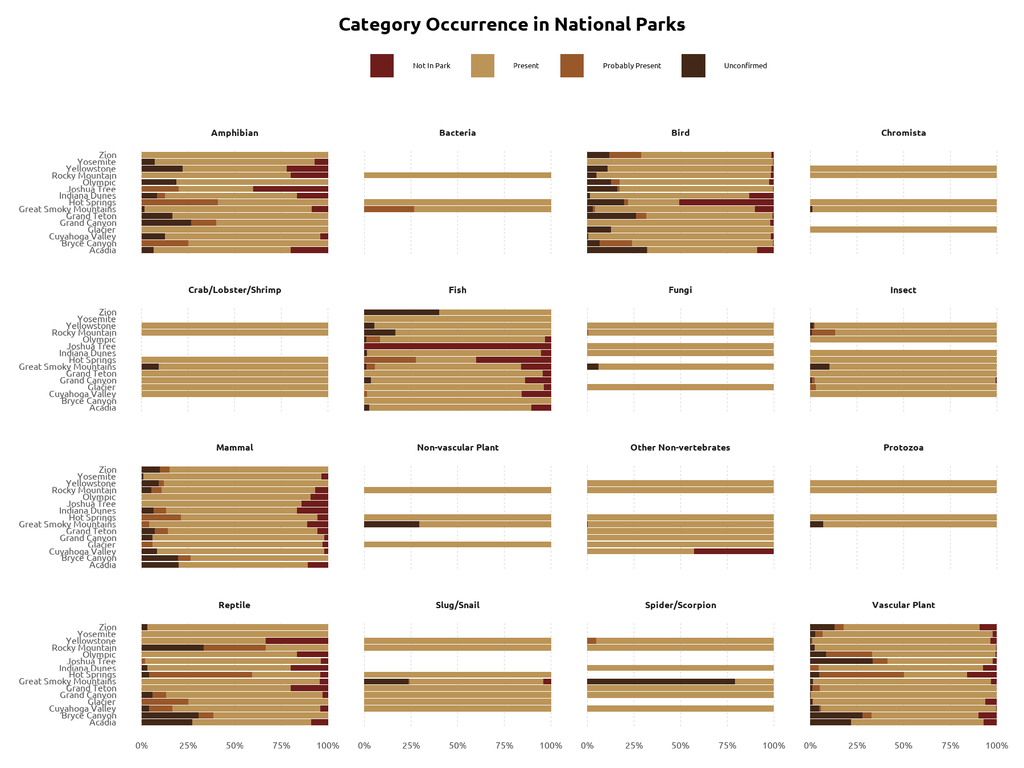

## Acadia National Park

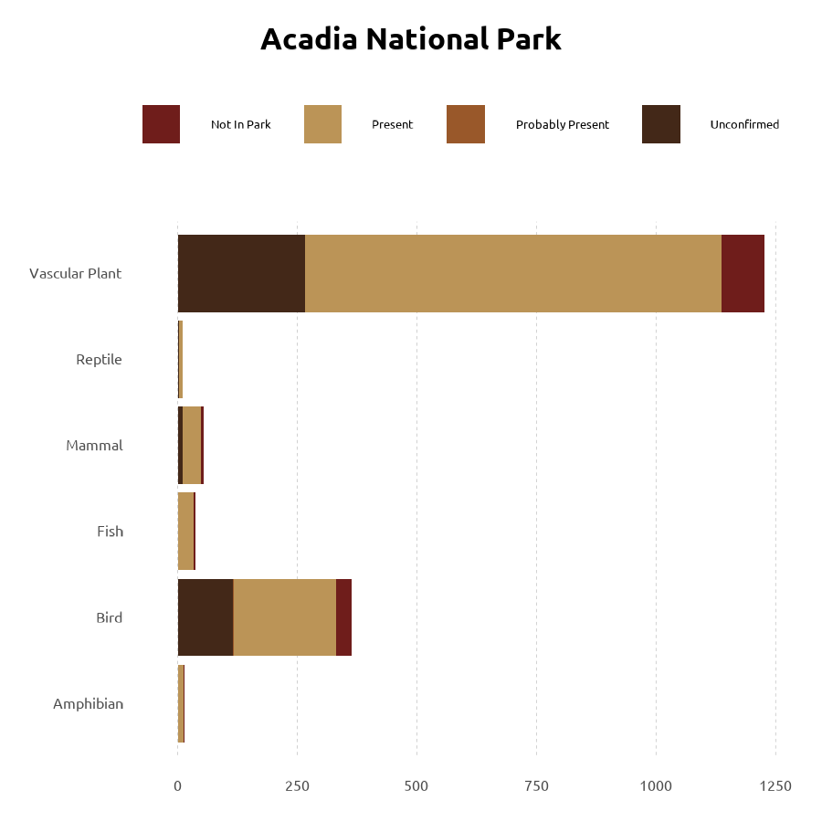

## Bryce Canyon National Park

This park lies in southern Utah. Since it’s a mountain park (it spans over 650 meters!) there is only 1 species of fish present but has a large diversity ofd plants and birds. It is famous for its spire rocks.

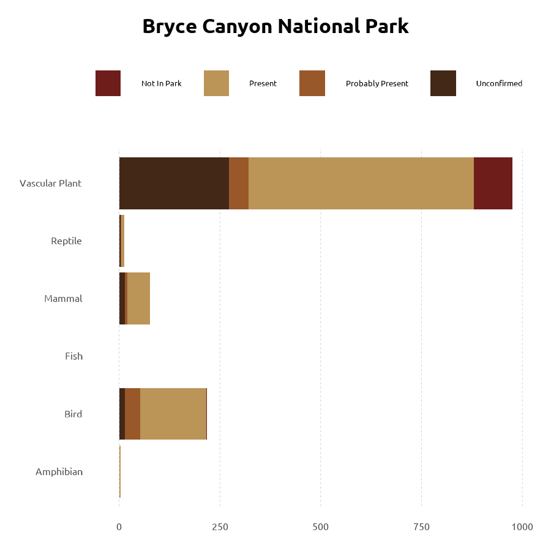

## Cuyahoga Valley National Park

This park lies close to Cleveland and Lake Erie. It is based around river Cuyahoga which provides it with a large diversity of categories of animals and plants.

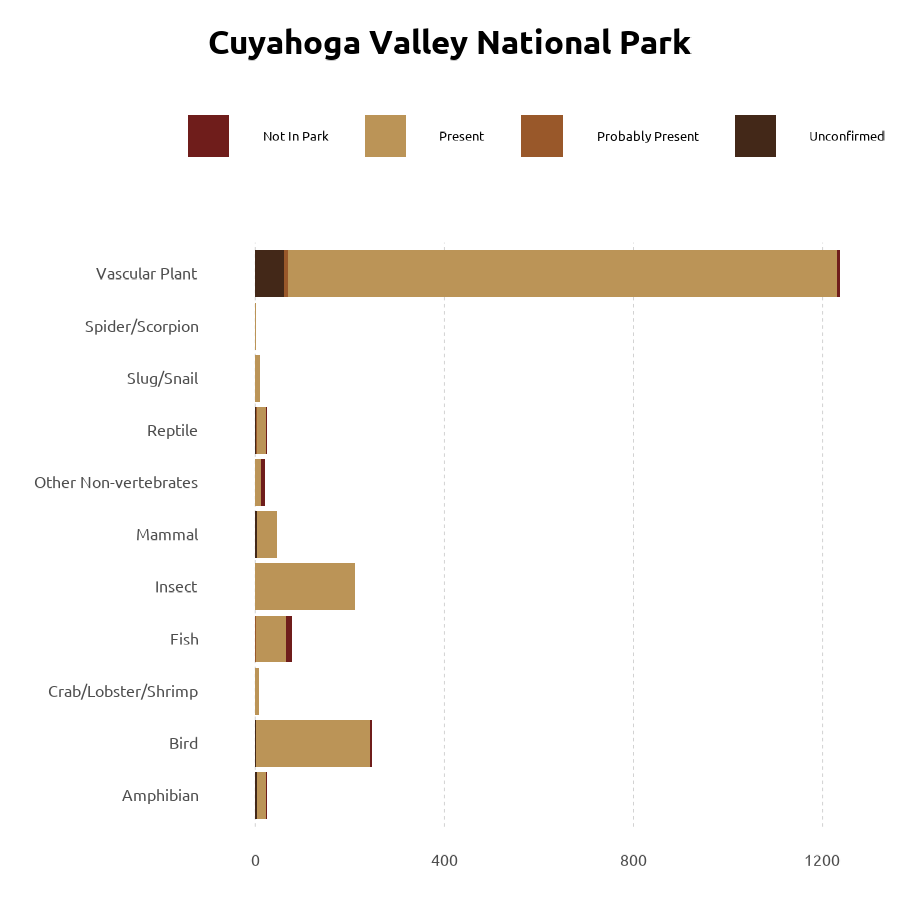

## Glacier National Park

The park is located in the very north of Montana close to the border with Canada. It is a host for multiple species of plants and mammals that thrive in the alpine climate

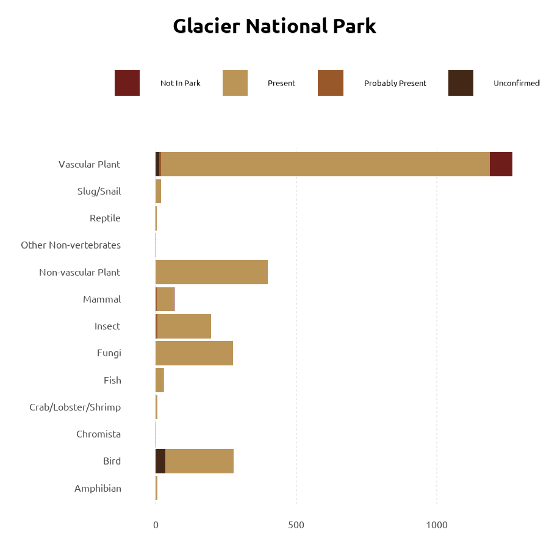

## Grand Canyon National Park

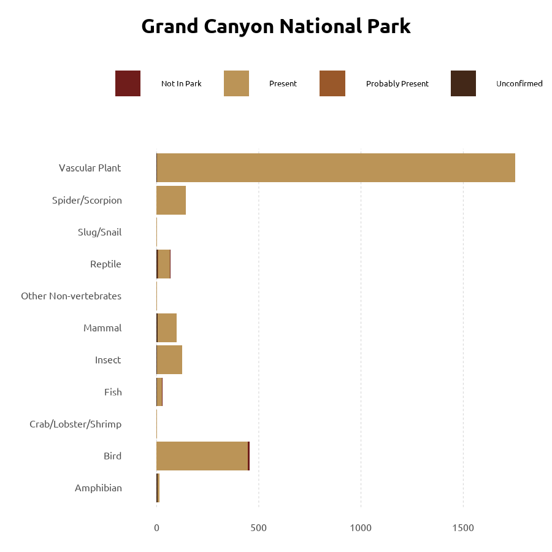

## Grand Teton National Park

This park is in northwestern Wyoming. This mountain-based park has a cold and snowy climate is the host for such species like Grizzly Bears and bull moose. It has beautiful glaciers, creeks, lakes and hot springs.

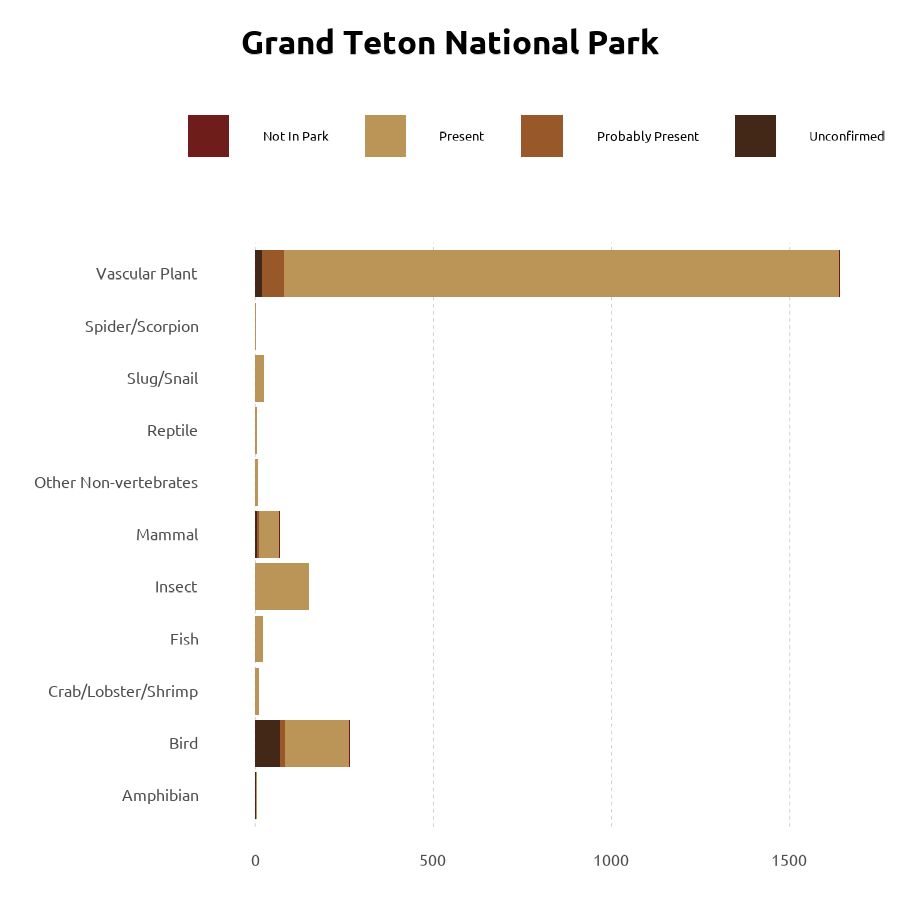

## Great Smoky Mountains National Park

This park is located in North Carolina has the largest number of insects, spiders and fungi out of all national parks described here. It has also a huge variety of other categories of living organisms making it the most biodiverse park in thew National Park System. Its mountain temperate climate and humid weather with abundance of rain make it possible for such diversity of organisms to live there

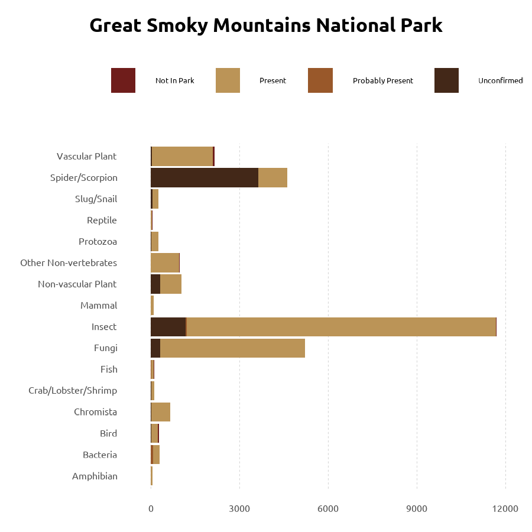

## Hot Springs National Park

As the name suggests the Hot Springs National Park is famous for its thermal springs and historic bathhouses. It does not have as many confirmed plant occurrences as the other parks. Located next to Hot springs in Arkansas the park is surrounded by mountians and forests. Unfortunately many species were lost due to hunting and loss of habitat before the park was expanded to protect the fauna and flora of the region.

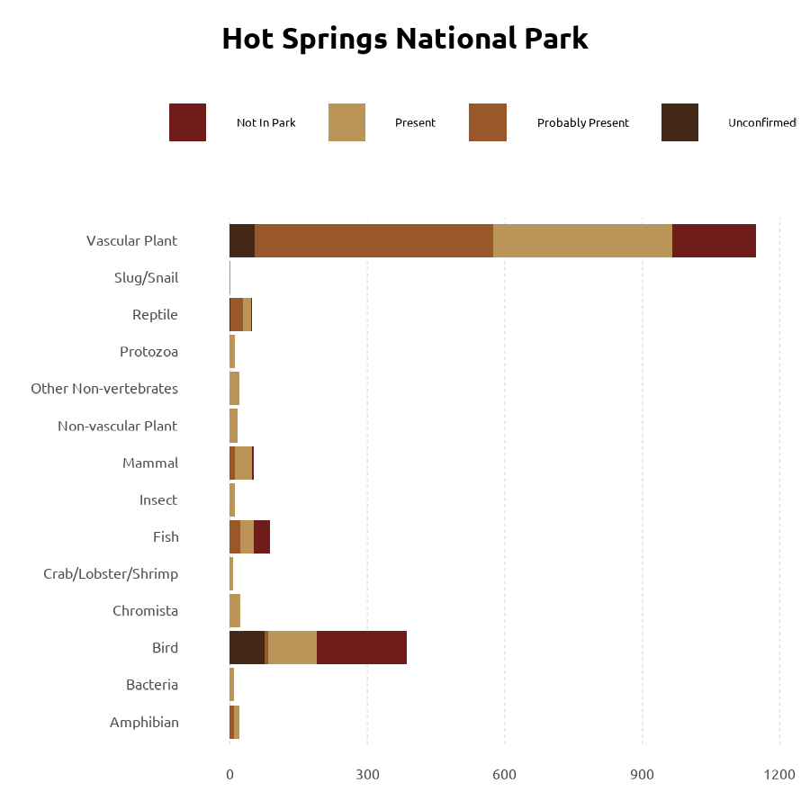

## Indiana Dunes National Park

This park is located by Lake Michigan in northern USA. It is best known for its shoreline and dunes that are host for many plants and bird species. It has fourth highest biodiversity among the national parks.

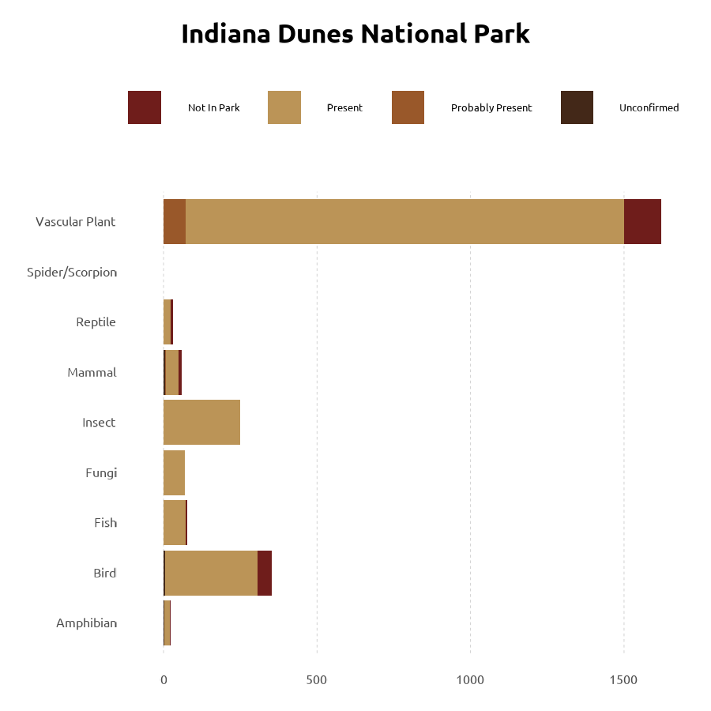

## Joshua Tree National Park

This park is located close to Palm springs in California between Colorado Desert, Mojave Desert and Little San Bernardino Mountains. Many species of birds can be sighted there because it lies on the Pacific flyway for migratory birds.

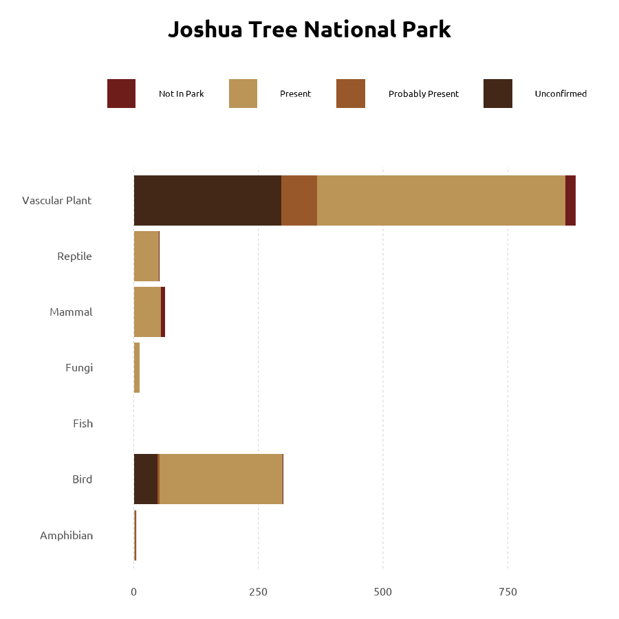

## Olympic National Park

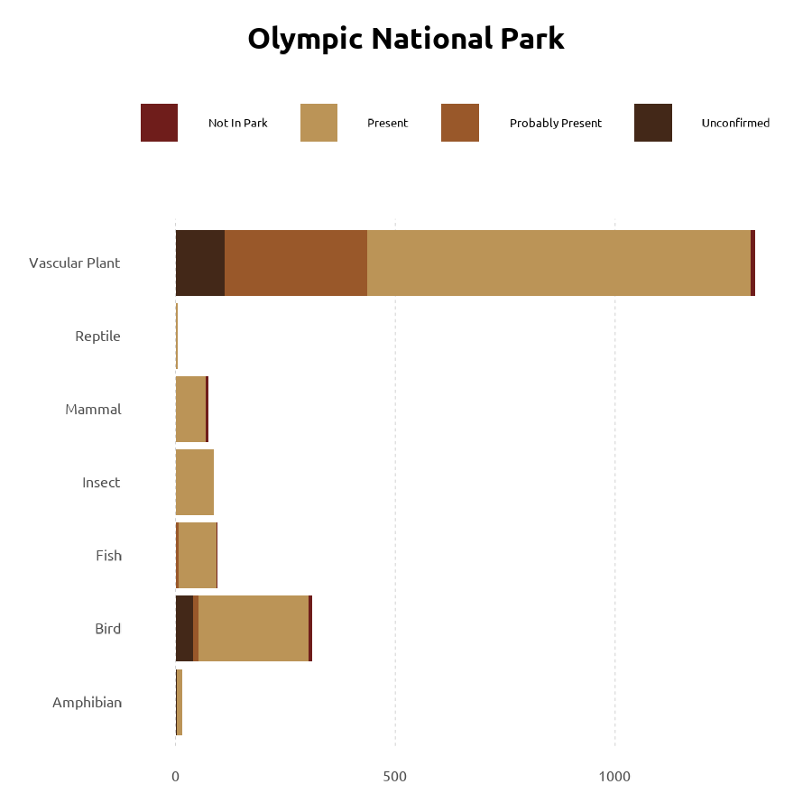

## Rocky Mountain National Park

This park lies close to Denver in Colorado. It’s elevation (from 7,860 feet to 14,259 feet) defines the unique features of this park, from large meadows to alpine lakes. It has a large variety of categories of living organisms with many plants, fungi and insects present.

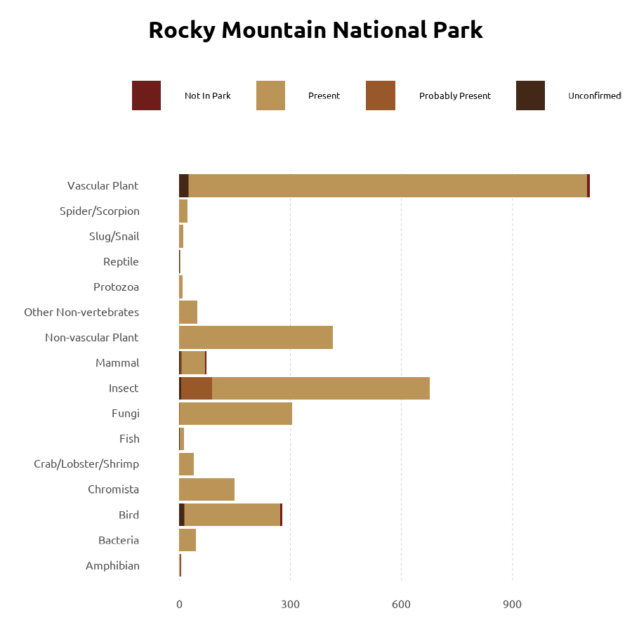

## Yellowstone National Park

This park is famous for its geysers and other hydrothermal areas. It is located in north western Wyoming. Its unique climate is home to a huge variety of insects and plants, especially thermophiles. Thanks to having been established early in the US history it was able to protect its varied wildlife.

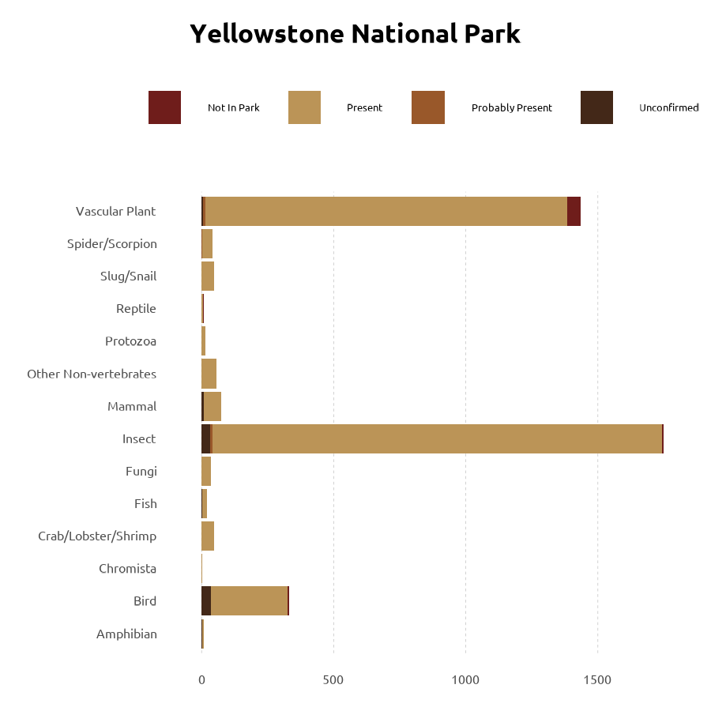

## Yosemite National Park

This park is located in California, over 200 kilometers east of San Francisco. It is most famous for its waterfalls, valleys and meadows. It is home to giant sequoias and over 1000 species of other plants.

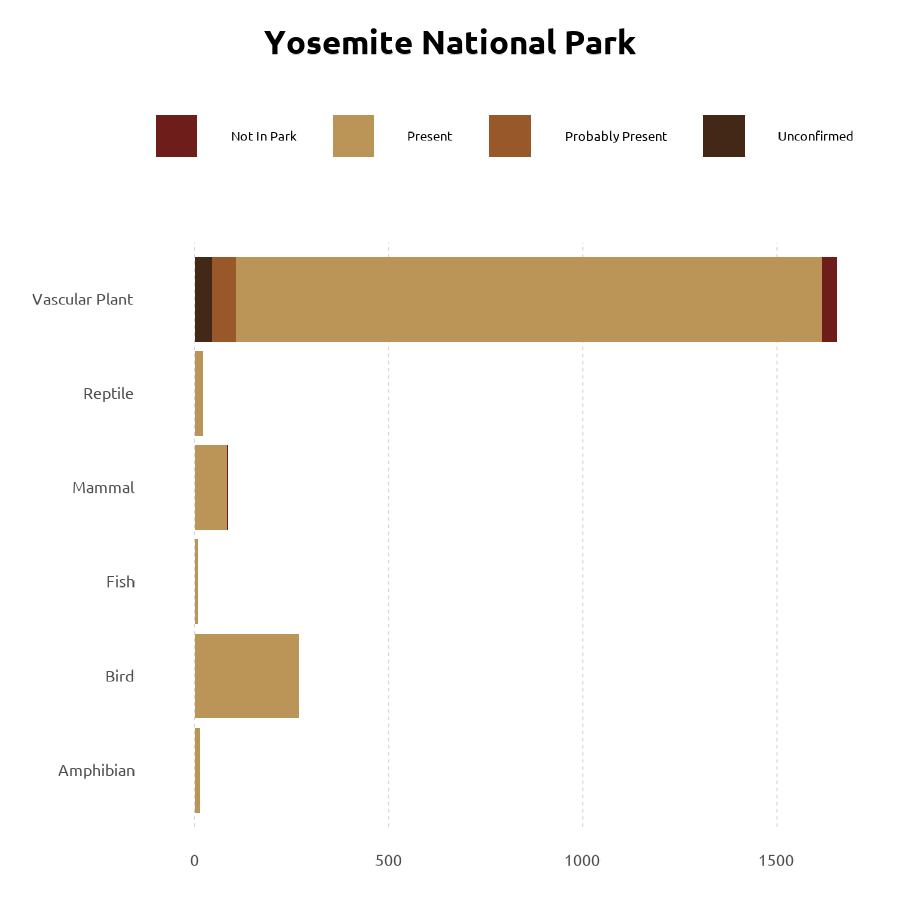

## Zion National Park

This park is located in southwestern Utah. Its large elevation change with over 5000 feet in the highest point it provides diverse habitats for many species of plants and animals. The meandering canyons and rivers are home to many plants and birds.

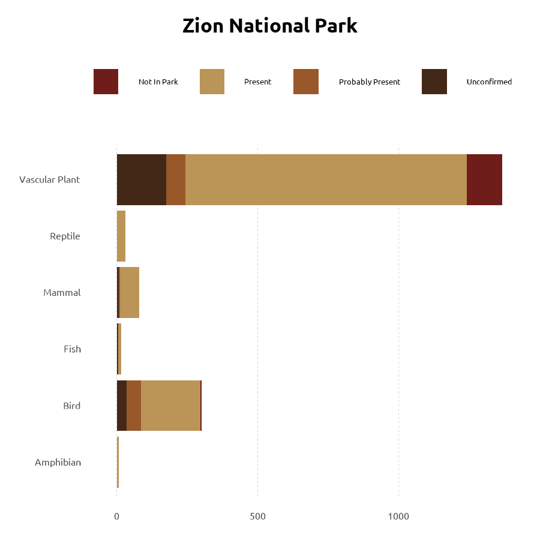

The parks are scattered across the US

Many are in the south west: Yosemite, Zion, Joshua Tree, Grand Canyon, and Bryce Canyon National Parks

Some are in the west north: Olympic, Glacier, Yellowstone and Grand Teton National Parks. Rocky Mountain National Park is closer to center US.

There are fewer parks east: Hot Springs, Indiana Dunes, Cuyahoga, Great Smoky Mountains and Acadia National Park.

Remember that these are just a subset of parks for which we have the data! There are 63 national parks in the USA!

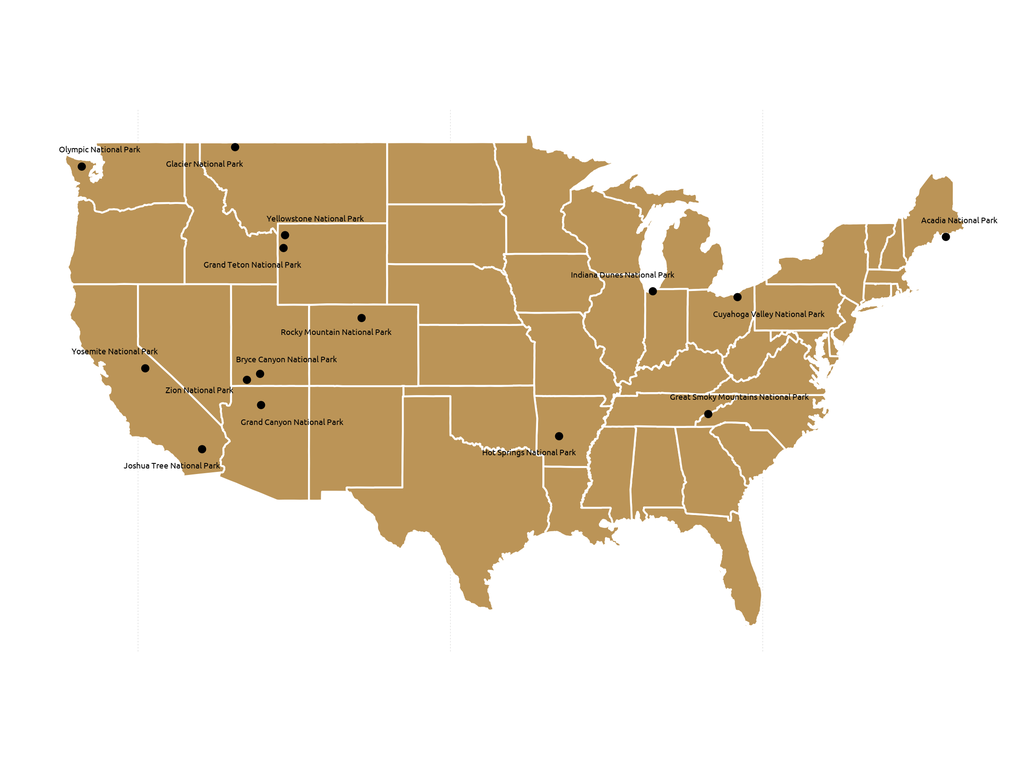

All information on the parks taken from the [National Park Service](https://www.nps.gov/index.htm) and the data was taken from [Tidytuesday week 41 2024](https://github.com/rfordatascience/tidytuesday/blob/master/data/2024/2024-10-08/readme.md)